# AMultinational Bank Customer Churn

T4-Analytical Avengers

2022-12-06

# EDA

**Reading the file with all the customer churn details as a data frame.Then displaying the structure of the data frame**

```r
churn_data<-data.frame(read.csv("Bank_Customer_Churn_Prediction.csv",header=TRUE)) #reading the file into data frame
str(churn_data) #printing the data frame structure
```

```
## 'data.frame':    10000 obs. of  12 variables:
##  $ customer_id     : int  15634602 15647311 15619304 15701354 15737888 15574012 15592531 15656148 15792365 15592389 ...
##  $ credit_score    : int  619 608 502 699 850 645 822 376 501 684 ...
##  $ country         : chr  "France" "Spain" "France" "France" ...
##  $ gender          : chr  "Female" "Female" "Female" "Female" ...
##  $ age             : int  42 41 42 39 43 44 50 29 44 27 ...
##  $ tenure          : int  2 1 8 1 2 8 7 4 4 2 ...
##  $ balance         : num  0 83808 159661 0 125511 ...
##  $ products_number : int  1 1 3 2 1 2 2 4 2 1 ...
##  $ credit_card     : int  1 0 1 0 1 1 1 1 0 1 ...
##  $ active_member   : int  1 1 0 0 1 0 1 0 1 1 ...
##  $ estimated_salary: num  101349 112543 113932 93827 79084 ...
##  $ churn           : int  1 0 1 0 0 1 0 1 0 0 ...
```

The churn data frame as 10000 customers from the with each customer having 12 following attributes; Customer ID :The Unique ID of each individual customer Credit Score : A number depicting the customer’s creditworthiness Country : The country the customer banks from Gender : The gender the customer identifies with Age : Depicts the customers age Tenure : Indicates how length in years the customer has been with the bank Balance : The amount currently available in the customer’s account Products Number : The number of products purchased by the customer through the bank Credit Card : Indicates the customer has a credit card Active Member : Indicates if the customer is an active or inactive Estimated Salary : Bank Estimation of the income of the customer Churn : Indicator of if the customer has left the bank or not

**Checking for duplicates in the data frame.**

```r
nrow(unique(churn_data)) #checking for unique rows
```

There are 10000 rows of unique records in the data.Hence we the data frame has no duplicates records.We can proceed with next step of analysis.

**Checking if there are any NA values in the data frame**

```r
sum(is.na(churn_data) == 'TRUE') # checking for NA values in the dataframe
```

We found that our dataset was clean without any NA values.

**Checking for summary of the churn data frame.**

```r
summary(churn_data) #looking for summary of the data frame
```

```
##   customer_id        credit_score   country             gender
##  Min.   :15565701   Min.   :350   Length:10000       Length:10000
##  1st Qu.:15628528   1st Qu.:584   Class :character   Class :character
##  Median :15690738   Median :652   Mode  :character   Mode  :character
##  Mean   :15690941   Mean   :651
##  3rd Qu.:15753234   3rd Qu.:718
##  Max.   :15815690   Max.   :850
##       age           tenure         balance       products_number
##  Min.   :18.0   Min.   : 0.00   Min.   :     0   Min.   :1.00
##  1st Qu.:32.0   1st Qu.: 3.00   1st Qu.:     0   1st Qu.:1.00
##  Median :37.0   Median : 5.00   Median : 97199   Median :1.00
##  Mean   :38.9   Mean   : 5.01   Mean   : 76486   Mean   :1.53
##  3rd Qu.:44.0   3rd Qu.: 7.00   3rd Qu.:127644   3rd Qu.:2.00
##  Max.   :92.0   Max.   :10.00   Max.   :250898   Max.   :4.00
##   credit_card    active_member   estimated_salary     churn
##  Min.   :0.000   Min.   :0.000   Min.   :    12   Min.   :0.000
##  1st Qu.:0.000   1st Qu.:0.000   1st Qu.: 51002   1st Qu.:0.000
##  Median :1.000   Median :1.000   Median :100194   Median :0.000
##  Mean   :0.706   Mean   :0.515   Mean   :100090   Mean   :0.204
##  3rd Qu.:1.000   3rd Qu.:1.000   3rd Qu.:149388   3rd Qu.:0.000
##  Max.   :1.000   Max.   :1.000   Max.   :199992   Max.   :1.000
```

Credit score:We see that minimum credit score of the customer is 350 with average score being 651 and 850 being maximum score. Age:Minimum age of the customer is 18 with average age being 38.9 and maximum age being 92. Tenure:The customers has been with bank for an average of 5 years and upto 10 years. Balance:Maximum account balance of the cutsomer is 250898 with average balance being 76486. Country,gender,active member,credit card,product n umber and churn are categorical variables.

**Customer ID is not an important attribute that impacts churn rate**

```r
churn_data <- churn_data[-c(1)] # removing column 1(customer _id) from data set
ncol(churn_data) # counting number of variables in the data frame
str(churn_data) # checking for summary of the data frame after removing the customer_if field
```

We are not making analysis for each customer,Hence customer_id was irrelevant field in the data set so we decided to remove the customer_id column from the data frame. After removing customer_id attribute from the data frame we now have 11 columns.

## Independent variable EDA

**Converting required variables into categorical values**

```r
str(churn_data)
churn_data_category=churn_data
churn_data_category$credit_card=factor(churn_data$credit_card)
churn_data_category$active_member=factor(churn_data$active_member)
churn_data_category$churn=factor(churn_data$churn)
churn_data_category$gender=factor(churn_data$gender)
churn_data_category$tenure =factor(churn_data$tenure )
churn_data_category$products_number=factor(churn_data$products_number)
churn_data_category$age=factor(churn_data$age)
str(churn_data_category)
```

We decided to convert these variables into categorical (factor):  
`credit_card`, `active_member`, `churn` and `gender`,`product_number`,`tenure`,`age`. Notice that the data frame `churn_data` still has all variables numerical, while the data frame `churn_data_category` include categorical columns that we just converted.

**Converting Boolean values into Character format**

```r
churn_data$active_member[churn_data$active_member== 1]<-"Active"
churn_data$active_member[churn_data$active_member== 0]<-"In Active"

churn_data$credit_card[churn_data$credit_card== 1]<-"Credit Card"
churn_data$credit_card[churn_data$credit_card== 0]<-"No-Credit Card"

churn_data$churn[churn_data$churn== 1]<-"Churned"
churn_data$churn[churn_data$churn== 0]<-"Retained"

head(churn_data)
```

We decided to assign string values to the corresponding Boolean values for the few variables in the dataset,So that it would be much better to understand each variable clearly.

### Ouliers For Customer data

*Checking for outliers in the data frame for credit_score,age,tenure,balance,estimated_salary variables using outlierKD function.*

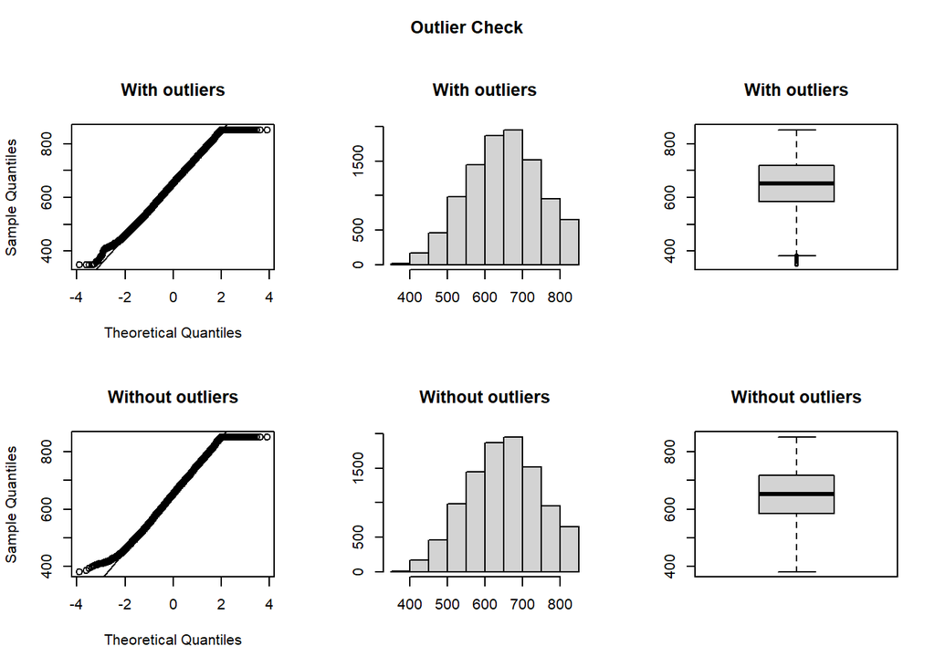

```r
credit_score_clean <- outlierKD2(churn_data, credit_score, rm = TRUE, boxplt = TRUE, qqplt = TRUE)
```

```r
xkablesummary(credit_score_clean)
```

The proportion outliers for credit_score variable if 0.2% and it was removed successfully using outlierKD function.

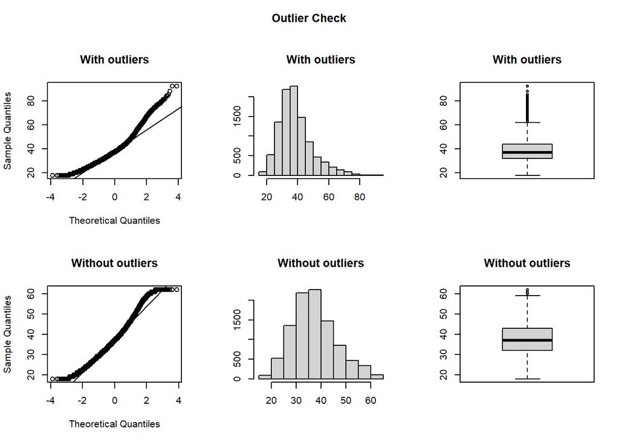

```r
age_clean <- outlierKD2(churn_data, age, rm = TRUE, boxplt = TRUE, qqplt = TRUE)
```

```r
xkablesummary(age_clean)
```

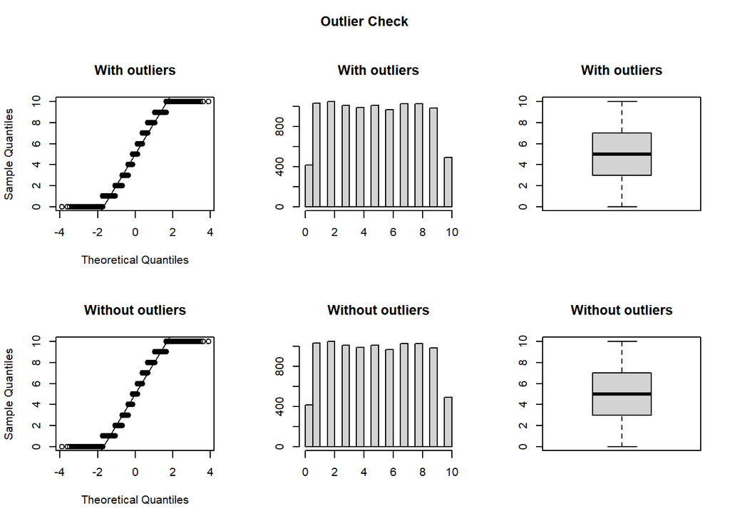

```r
tenure_clean <- outlierKD2(churn_data, tenure, rm = TRUE, boxplt = TRUE, qqplt = TRUE)
```

```r
xkablesummary(tenure_clean)
```

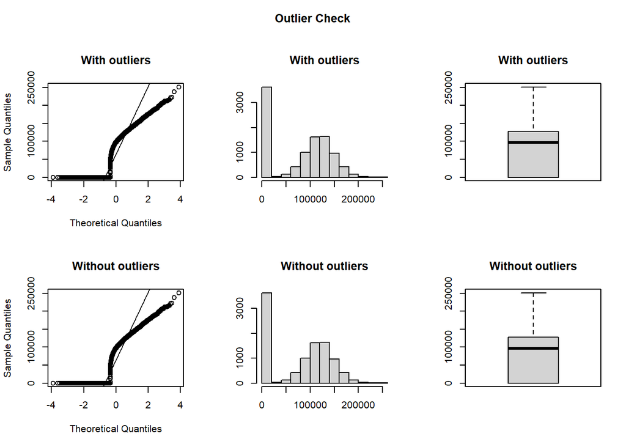

```r
balance_clean <- outlierKD2(churn_data, balance, rm = TRUE, boxplt = TRUE, qqplt = TRUE)
```

```r
xkablesummary(balance_clean)
```

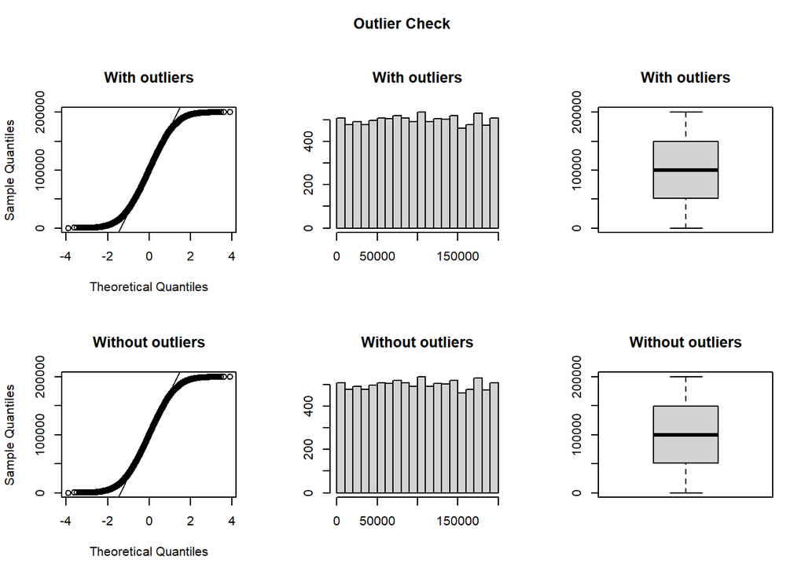

```r
salary_clean <- outlierKD2(churn_data, estimated_salary, rm = TRUE, boxplt = TRUE, qqplt = TRUE)
```

```r
xkablesummary(salary_clean)
```

By using outlierKD function we can observe that outliers where found only in `age` and `credit_score` variables i.e,3.7% and 0.2%,So we decided to remove using outlierKD function.

### Customer Analysis

Analyzing each variable in the dataframe by using the relevant plots along with the calculated mean,SD and percentages.

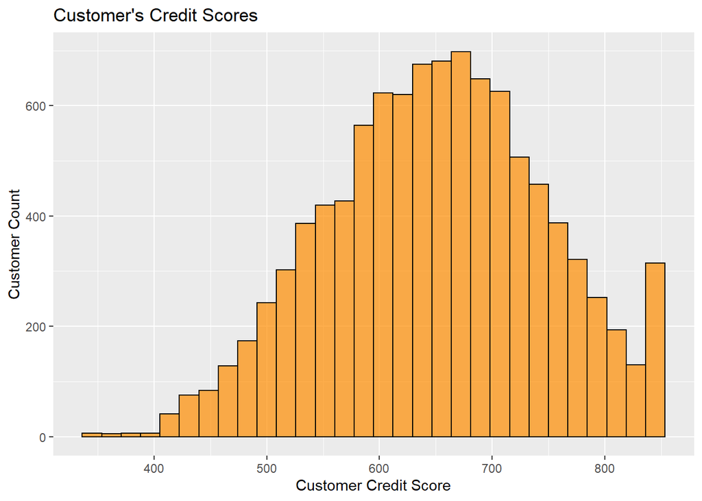

```r
library(ggplot2)
ggplot(data=churn_data, aes(x=credit_score)) +
  geom_histogram(col="black",bins=30,
                 fill="dark orange",
                  alpha =.7) + # opacity
  labs(title="`ggplot`") +
  labs(title="Customer's Credit Scores",x="Customer Credit Score", y="Customer Count")
```

```r
print(mean(churn_data$credit_score))
print(sd(churn_data$credit_score))
```

**The average `credit score` of the customer is 650.529,most of the customer having credit score fall between 600 to 700 and standard deviation is 96.653.**

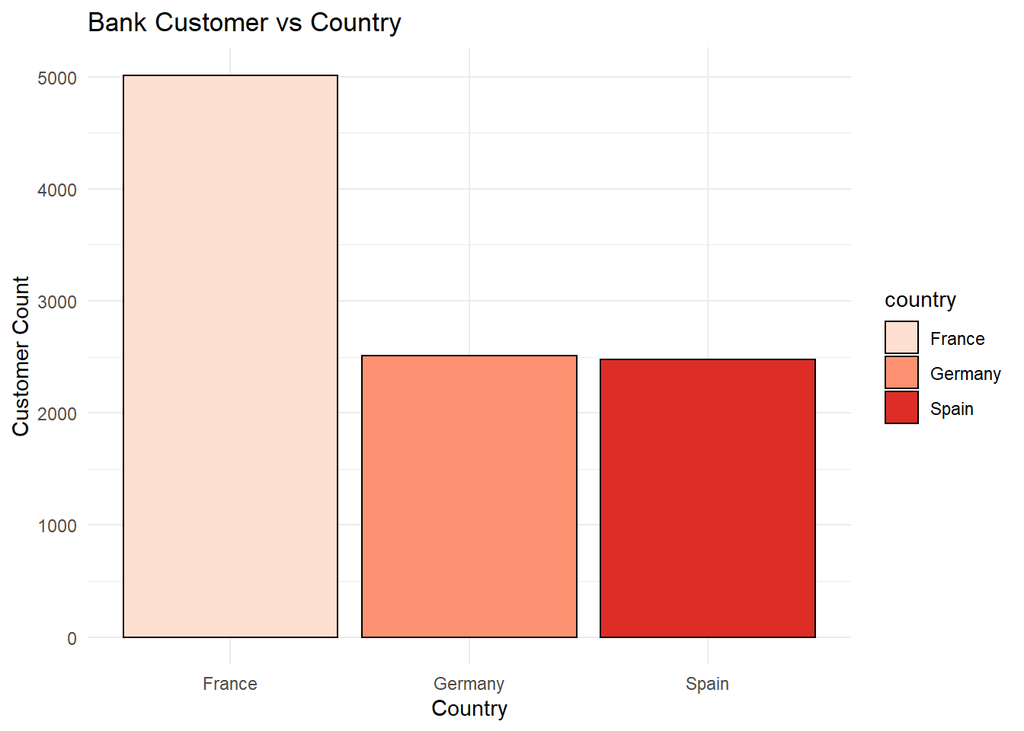

```r
ggplot(data=churn_data,aes(x=country,fill=country))+
  geom_bar(col="black")+
  scale_fill_brewer(palette="Reds") +
  labs(title = "Bank Customer vs Country",x="Country",y="Customer Count")+
  theme_minimal()
```

**The customers are grouped by the countries in which they have their accounts.As we see from the plot France has more than 50% of customer account which is the highest among all other countries with Germany and Spain sharing equal percentages.**

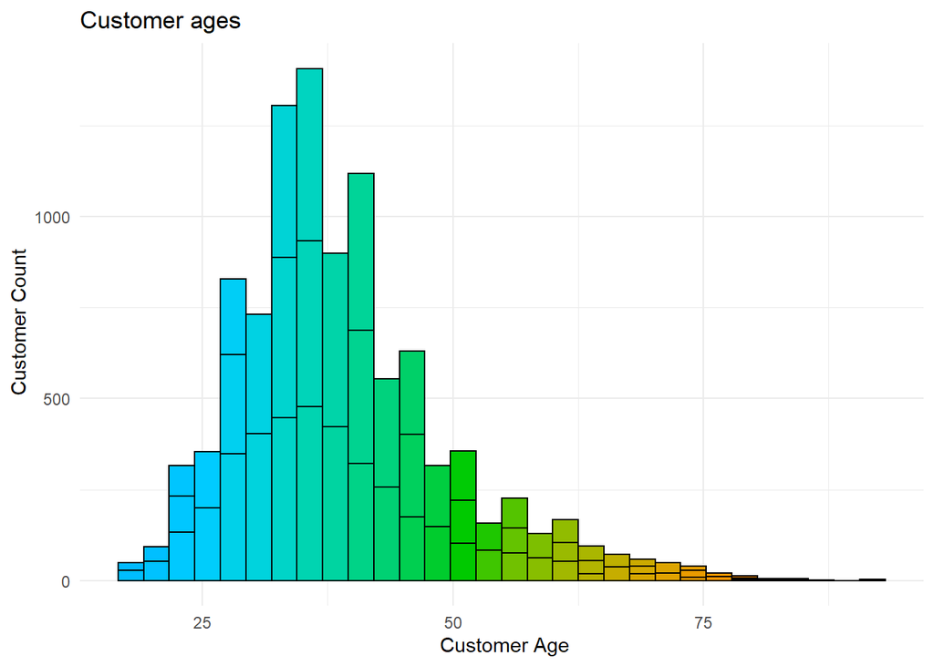

```r
ggplot(churn_data, aes(x = age,fill=cut(age,100))) +
  geom_histogram(show.legend = FALSE,col="black",bins=30)+
  scale_fill_discrete(h=c(240,10),c=120,l=70)+
  theme_minimal()+
  labs(x=" Customer Age",y=" Customer Count")+
  ggtitle("Customer ages")
```

```r
print(mean(churn_data$age))
print(sd(churn_data$age))
```

**The majority of the bank customer’s fall below the age of 50 with average age of 38.922 and with standard deviation of 10.488.**

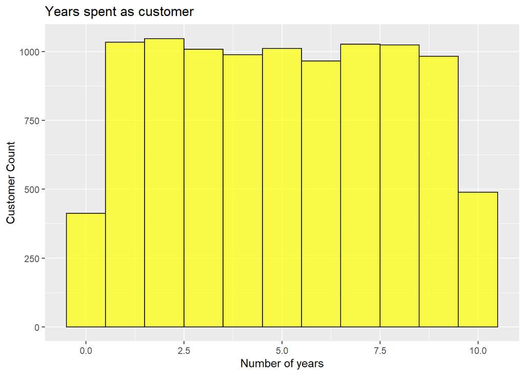

```r
library(ggplot2)
ggplot(data=churn_data, aes(x=tenure)) +
  geom_histogram(col="black",bins=11,
                 fill="Yellow",
                  alpha =.7) +
  labs(title="Years spent as customer",x="Number of years", y="Customer Count")
```

**Most of the customer as been with bank for more than a year.**

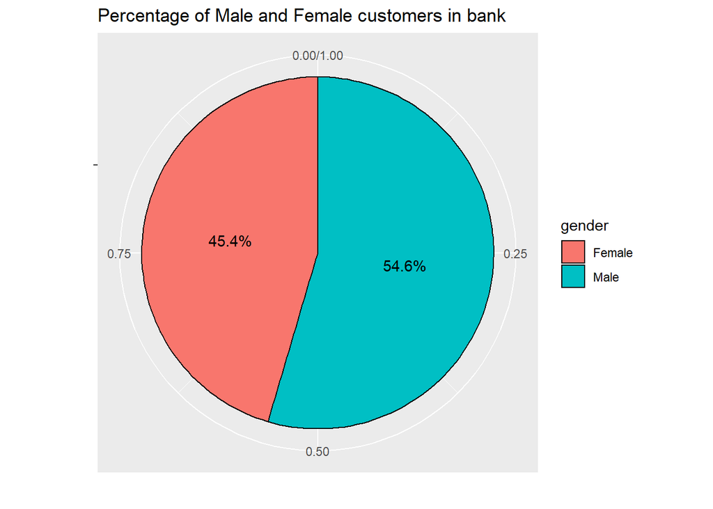

```r
df <- churn_data %>%
  group_by(gender) %>% # Variable to be transformed
  count() %>%
  ungroup() %>%
  mutate(perc = `n` / sum(`n`)) %>%
  arrange(perc) %>%
  mutate(labels = scales::percent(perc))
str(df)

ggplot(df, aes(x = "", y = perc, fill =gender )) +
  geom_col(color="black") +
  geom_text(aes(label = labels),color = c("black", "black"),
            position = position_stack(vjust = 0.5)) +
  coord_polar(theta = "y")+
  labs(title="Percentage of Male and Female customers in bank",x="", y="")
```

**The Male customers are highest in percent of 55% and remaining 45% are Female customers.**

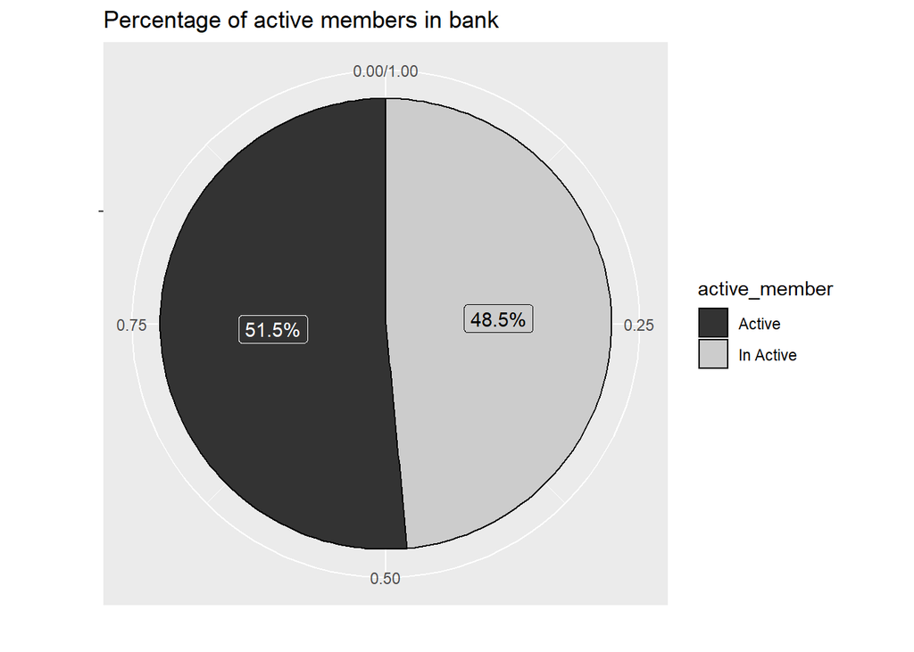

```r
df <- churn_data %>%
  group_by(active_member) %>% # Variable to be transformed
  count() %>%
  ungroup() %>%
  mutate(perc = `n` / sum(`n`)) %>%
  arrange(perc) %>%
  mutate(labels = scales::percent(perc))
str(df)


ggplot(df, aes(x = "", y = perc, fill = active_member)) +
  geom_col(color="black") +
  geom_label(aes(label = labels),color = c("black", "white"),
             position = position_stack(vjust = 0.5),
             show.legend = FALSE) +
  coord_polar(theta = "y")+
  scale_fill_grey()+
  labs(title="Percentage of active members in bank",x="", y="")
```

**Huge percentage of customer are being inactive,it is reported that 48.5% of customers are being inactive.**

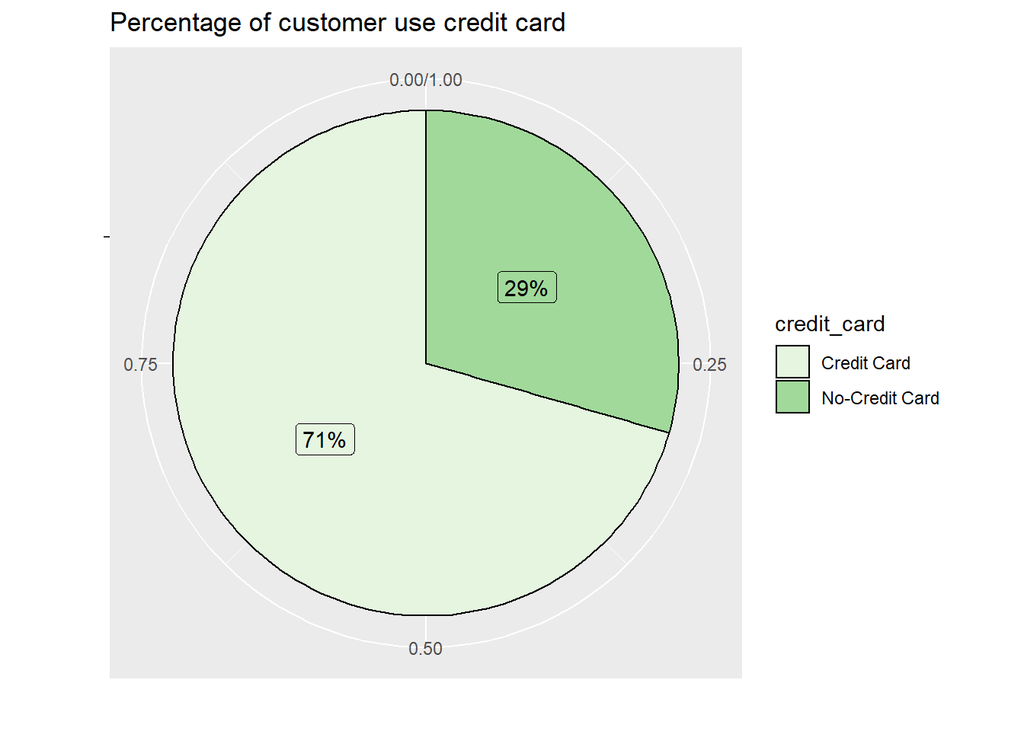

```r
df <- churn_data %>%
  group_by(credit_card) %>% # Variable to be transformed
  count() %>%
  ungroup() %>%
  mutate(perc = `n` / sum(`n`)) %>%
  arrange(perc) %>%
  mutate(labels = scales::percent(perc))
str(df)

ggplot(df, aes(x = "", y = perc, fill = credit_card)) +
  geom_col(color="black") +
  geom_label(aes(label = labels),color = c("black", "black"),
             position = position_stack(vjust = 0.5),
             show.legend = FALSE) +
  coord_polar(theta = "y")+
  scale_fill_brewer(palette="Greens")+
  labs(title="Percentage of customer use credit card",x="", y="")
```

**Predominantly 71% of the Bank customer use credit_card and only 29% do not make use of it.**

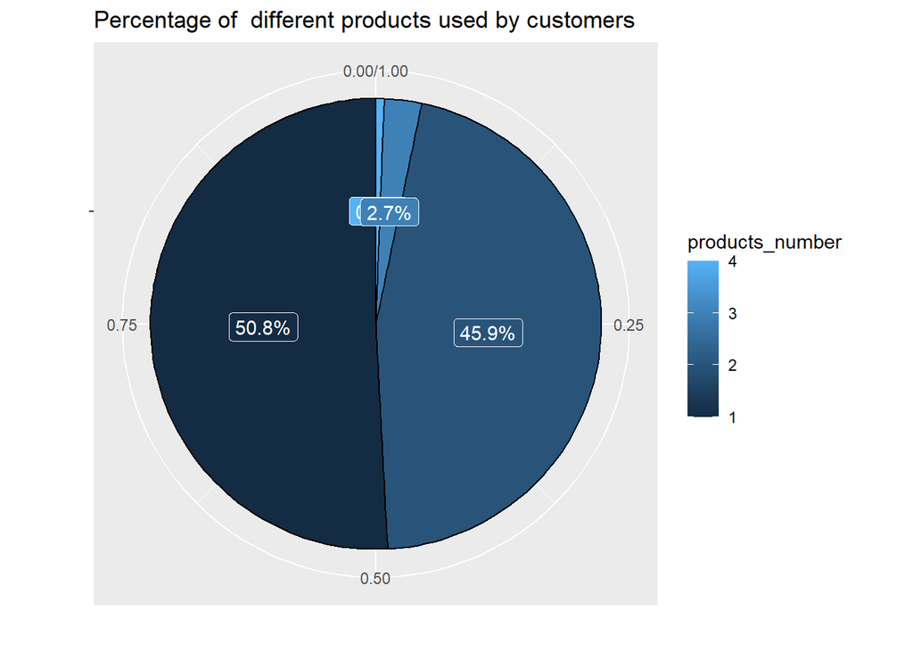

```r
df <- churn_data %>%
  group_by(products_number) %>% # Variable to be transformed
  count() %>%
  ungroup() %>%
  mutate(perc = `n` / sum(`n`)) %>%
  arrange(perc) %>%
  mutate(labels = scales::percent(perc))
str(df)

ggplot(df, aes(x = "", y = perc, fill = products_number)) +
  geom_col(color="black") +
  geom_label(aes(label = labels),color = c("white", "white","white","white"),
             position = position_stack(vjust = 0.5),
             show.legend = FALSE) +
  coord_polar(theta = "y")+
  labs(title="Percentage of  different products used by customers ",x="", y="")
```

**Most of the customer user product 1 which is 50% and product 4 is the least used with 0.6%.**

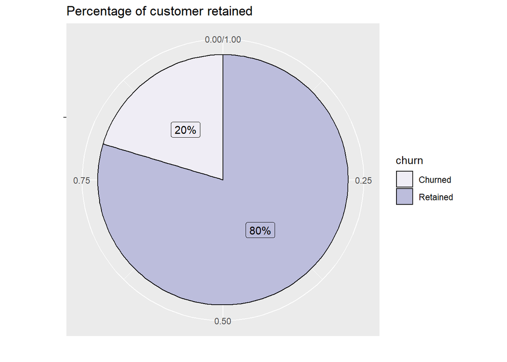

```r
df <- churn_data %>%
  group_by(churn) %>%
  count() %>%
  ungroup() %>%
  mutate(perc = `n` / sum(`n`)) %>%
  arrange(perc) %>%
  mutate(labels = scales::percent(perc))
str(df)

ggplot(df, aes(x = "", y = perc, fill = churn)) +
  geom_col(color="black") +
  geom_label(aes(label = labels),color = c("black", "black"),
             position = position_stack(vjust = 0.5),
             show.legend = FALSE) +
  coord_polar(theta = "y")+
  scale_fill_brewer(palette="Purples")+
  labs(title="Percentage of customer retained",x="", y="")
```

**The bank managed to retain 80% of their customers with the remaining 20% where churned out.**

## Inferential statstics

**Inferential statistics for customer credit scores**

```r
mean.credit_score = mean(churn_data$credit_score, na.rm = TRUE); #mean of the customer credit scores
str(mean.credit_score)
```

```
##  num 651
```

```r
sd_credit_score = sd(churn_data$credit_score)
str(sd_credit_score)
```

```
##  num 96.7
```

Mean and SD for the entire population of credit_score in churn_data data frame mean=650.53 and sd=96.653.

Now let us create a smaller sample of the credit score out of the entire population, and call it churn_credit_sample.

```r
set.seed(321)
churn_credit_sample = churn_data[ sample(nrow(churn_data),4000), ]
format(mean(churn_credit_sample$credit_score), digits=5)
```

```
## [1] "650.19"
```

```r
loadPkg("BSDA")

ztestcredit95 = z.test(churn_credit_sample$credit_score, sigma.x = 96.7) # default conf.level = 0.95
ztestcredit95
ztestcredit99 = z.test(churn_credit_sample$credit_score, sigma.x = 96.7, conf.level=0.99 )
ztestcredit99
ztestcredit50 = z.test(churn_credit_sample$credit_score, sigma.x = 96.7, conf.level=0.50 )
ztestcredit50

ztestcredit95$conf.int
ztestcredit99$conf.int
ztestcredit50$conf.int
```

```r
loadPkg("BSDA")

ttestcredit95 = t.test(churn_credit_sample$credit_score) # default conf.level = 0.95
ttestcredit95
ttestcredit99 = t.test(churn_credit_sample$credit_score, conf.level=0.99 )
ttestcredit99
ttestcredit50 = t.test(churn_credit_sample$credit_score,  conf.level=0.50 )
ttestcredit50

ttestcredit95$conf.int
ttestcredit99$conf.int
ttestcredit50$conf.int
```

**Inferential statistics for customer account balance.**

```r
mean.balance= mean(churn_data$balance, na.rm = TRUE); #mean of the customer account balance
str(mean.balance)
```

```
##  num 76486
```

```r
sd_balance = sd(churn_data$balance)
str(sd_balance)
```

```
##  num 62397
```

Now let us create a smaller sample of the account balance out of the entire population, and call it churn_balance_sample.

```r
set.seed(321)
churn_balance_sample = churn_data[ sample(nrow(churn_data),4000), ]
format(mean(churn_balance_sample$balance), digits=5)
```

```
## [1] "75942"
```

```r
loadPkg("BSDA")

ztestbalance95 = z.test(churn_balance_sample$balance, sigma.x = 62397.4) # default conf.level = 0.95
ztestbalance95
ztestbalance99 = z.test(churn_balance_sample$balance, sigma.x = 62397.4, conf.level=0.99 )
ztestbalance99
ztestbalance50 = z.test(churn_balance_sample$balance, sigma.x = 62397.4, conf.level=0.50 )
ztestbalance50

ztestbalance95$conf.int
ztestbalance99$conf.int
ztestbalance50$conf.int
```

```r
loadPkg("BSDA")

ttestbalance95 = t.test(churn_balance_sample$balance) # default conf.level = 0.95
ttestbalance95
ttestbalance99 = t.test(churn_balance_sample$balance, conf.level=0.99 )
ttestbalance99
ttestbalance50 = t.test(churn_balance_sample$balance,  conf.level=0.50 )
ttestbalance50

ttestbalance95$conf.int
ttestbalance99$conf.int
ttestbalance50$conf.int
```

## Churned Customer Analysis

### SMART Questions:

### Does churn depend on Gender?

**We are doing chi-square test to determine if the churn rate depends on Gender?**

Chi Square Test for independence

H0: Customer’s gender and churn are independent

H1: Customer’s gender and churn are not independent

```r
#Contingency table
contab = table(churn_data$churn, churn_data$gender)
xkabledply(contab, title="Contingency table for Gender(Male, Female) vs Churn (0 or 1)")

#Chisquare Test of independency
chitests = chisq.test(contab)
chitests

chitests$statistic
chitests$parameter
chitests$p.value
```

We have $\chi^2$ value of the test from `chitests$statistic` = 112.919,while extracting the p-value from `chitests$p.value` = 2.248^{-26} which is less than significance level of 0.05 ,Hence we reject the null hypothesis H0 and we conclude that the churn rate dependent on gender of the customer.

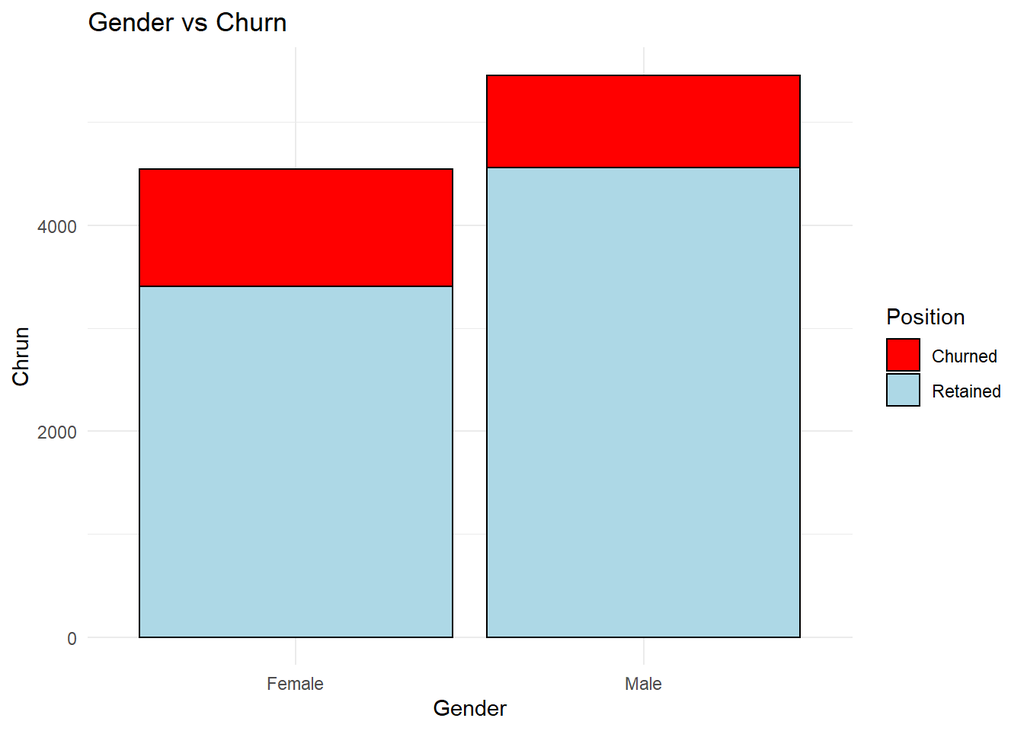

```r
ggplot(data=churn_data,aes(x=gender,fill=churn))+
  geom_bar(col="black")+
   scale_fill_manual('Position', values=c('red', 'lightblue'))+
  labs(title = "Gender vs Churn",x="Gender",y="Chrun")+
  theme_minimal()
```

We observed that majority of the churned customers were female despite the total population of the bank being predominantly male.